# UK Gender Pay Gap 2025 — Exploratory Data Analysis

2026-05-05

# 1. Introduction

This report presents an exploratory data analysis (EDA) of the UK Gender Pay Gap (GPG) using data from the **Annual Survey of Hours and Earnings (ASHE)**, published by the Office for National Statistics (ONS) in 2025.

The gender pay gap is defined as the difference between men’s and women’s mean or median hourly pay, expressed as a percentage of men’s pay:

$$GPG = \frac{\text{Men's pay} -
\text{Women's pay}}{\text{Men's pay}} \times 100$$

A **positive** value indicates men earn more than women. A **negative** value indicates women earn more than men.

- Employment type (all employees, full-time, part-time)
- Age group
- Industry sector (SIC 2007)
- Occupation group (SOC 2020)
- UK region and nation
- Public vs private sector

# 2. Data & Methodology

## 2.1 Data source

The dataset is drawn from 25 ONS ASHE 2025 tables, each covering a different analytical dimension. The data is **aggregated at the group level** — it does not contain individual employee records. Each table provides median and mean hourly GPG figures, with separate sheets for all employees, full-time employees, and part-time employees.

Cells marked `x` in the source files indicate suppressed estimates where the ONS deemed the sample size insufficient for reliable publication. These were treated as missing values (`NA`) throughout the analysis.

## 2.2 Data loading & cleaning

```r
library(tidyverse)
library(broom)
library(scales)
library(patchwork)

setwd(dirname(rstudioapi::getActiveDocumentContext()$path))
source("DataLoading.R")
source("DataCleaning.R")
```

[output not shown]

```r
# Summary of the cleaned datasets
tribble(
  ~Dataset,         ~Rows, ~Dimensions,                      ~NAs,
  "df_age_clean",        nrow(df_age_clean),        "8 age groups × 3 emp types",   sum(is.na(df_age_clean$gpg_median)),
  "df_industry_clean",   nrow(df_industry_clean),   "19 industries × 3 emp types",  sum(is.na(df_industry_clean$gpg_median)),
  "df_occupation_clean", nrow(df_occupation_clean), "9 occupations × 3 emp types",  sum(is.na(df_occupation_clean$gpg_median)),
  "df_pubpriv_clean",    nrow(df_pubpriv_clean),    "3 sectors × 3 emp types",       sum(is.na(df_pubpriv_clean$gpg_median)),
  "df_region_clean",     nrow(df_region_clean),     "12 regions × 3 emp types",      sum(is.na(df_region_clean$gpg_median))
) %>%
  knitr::kable(caption = "Table 1: Summary of cleaned datasets")
```

Table 1: Summary of cleaned datasets

| Dataset | Rows | Dimensions | NAs |
| --- | --- | --- | --- |
| df_age_clean | 24 | 8 age groups × 3 emp types | 0 |
| df_industry_clean | 57 | 19 industries × 3 emp types | 2 |
| df_occupation_clean | 27 | 9 occupations × 3 emp types | 0 |
| df_pubpriv_clean | 9 | 3 sectors × 3 emp types | 0 |
| df_region_clean | 36 | 12 regions × 3 emp types | 0 |

# 3. Headline Findings

## 3.1 Overall gender pay gap

```r
overall <- df_age_clean %>%
  filter(emp_type == "All", description == "All employees")

ft <- df_age_clean %>%
  filter(emp_type == "Full-Time", description == "All employees")

pt <- df_age_clean %>%
  filter(emp_type == "Part-Time", description == "All employees")
```

The overall UK median GPG in 2025 is **12.8%** (mean: **13.4%**).

For **full-time** employees the median gap narrows to **6.9%**, while for **part-time** employees it is **-2.9%** — a negative figure, meaning women in part-time roles earn *more* than men on the median.

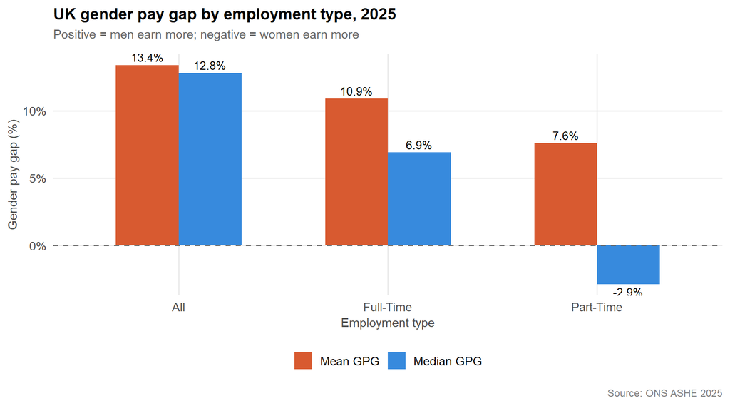

Figure 1: Overall GPG by employment type

```r
# Shared colour palette
COL_MEDIAN <- "#378ADD"
COL_MEAN   <- "#D85A30"
COL_POS    <- "#E24B4A"
COL_NEG    <- "#1D9E75"
COL_ALL    <- "#378ADD"
COL_FT     <- "#1D9E75"
COL_PT     <- "#BA7517"

theme_gpg <- function() {
  theme_minimal(base_size = 13) +
    theme(
      plot.title       = element_text(size = 14, face = "bold",
                                      margin = margin(b = 6)),
      plot.subtitle    = element_text(size = 11, colour = "grey40",
                                      margin = margin(b = 12)),
      plot.caption     = element_text(size = 9,  colour = "grey50",
                                      margin = margin(t = 10)),
      axis.title       = element_text(size = 11, colour = "grey30"),
      panel.grid.minor = element_blank(),
      panel.grid.major = element_line(colour = "grey92"),
      legend.position  = "bottom",
      legend.title     = element_blank()
    )
}

p1_data <- df_age_clean %>%
  filter(description == "All employees") %>%
  select(emp_type, gpg_median, gpg_mean) %>%
  pivot_longer(cols = c(gpg_median, gpg_mean),
               names_to = "metric", values_to = "value") %>%
  mutate(
    metric   = recode(metric,
                      gpg_median = "Median GPG",
                      gpg_mean   = "Mean GPG"),
    emp_type = factor(emp_type,
                      levels = c("All", "Full-Time", "Part-Time"))
  )

ggplot(p1_data, aes(x = emp_type, y = value, fill = metric)) +
  geom_col(position = "dodge", width = 0.6) +
  geom_hline(yintercept = 0, linetype = "dashed", colour = "grey40") +
  geom_text(aes(label = paste0(round(value, 1), "%"),
                vjust = ifelse(value >= 0, -0.4, 1.3)),
            position = position_dodge(width = 0.6), size = 3.5) +
  scale_fill_manual(values = c("Median GPG" = COL_MEDIAN,
                               "Mean GPG"   = COL_MEAN)) +
  scale_y_continuous(labels = function(x) paste0(x, "%")) +
  labs(
    title    = "UK gender pay gap by employment type, 2025",
    subtitle = "Positive = men earn more; negative = women earn more",
    x        = "Employment type",
    y        = "Gender pay gap (%)",
    caption  = "Source: ONS ASHE 2025"
  ) +
  theme_gpg()
```

> **Key finding:** The overall gap (12.8% median) is nearly double the full-time gap (6.9%), suggesting the gap is substantially driven by the concentration of women in part-time roles rather than pay inequality within comparable roles.

# 4. GPG by Age Group

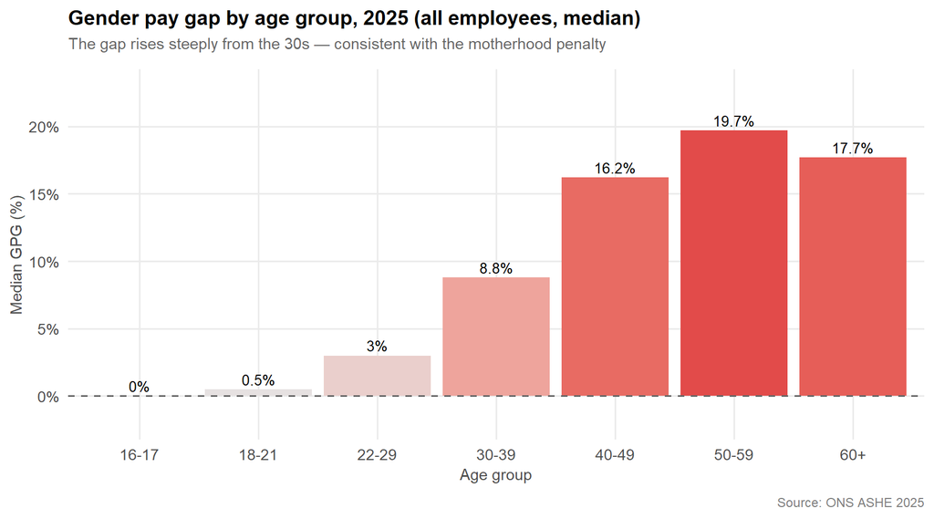

Figure 2: Median GPG by age group

```r
p2_data <- df_age_clean %>%
  filter(emp_type == "All", description != "All employees")

ggplot(p2_data, aes(x = description, y = gpg_median, fill = gpg_median)) +
  geom_col(show.legend = FALSE) +
  geom_hline(yintercept = 0, linetype = "dashed", colour = "grey40") +
  geom_text(aes(label = paste0(round(gpg_median, 1), "%"),
                vjust = -0.4), size = 3.5) +
  scale_fill_gradient2(low = COL_NEG, mid = "grey90",
                       high = COL_POS, midpoint = 0) +
  scale_y_continuous(labels = function(x) paste0(x, "%"),
                     limits = c(-2, 23)) +
  labs(
    title    = "Gender pay gap by age group, 2025 (all employees, median)",
    subtitle = "The gap rises steeply from the 30s — consistent with the motherhood penalty",
    x        = "Age group",
    y        = "Median GPG (%)",
    caption  = "Source: ONS ASHE 2025"
  ) +
  theme_gpg()
```

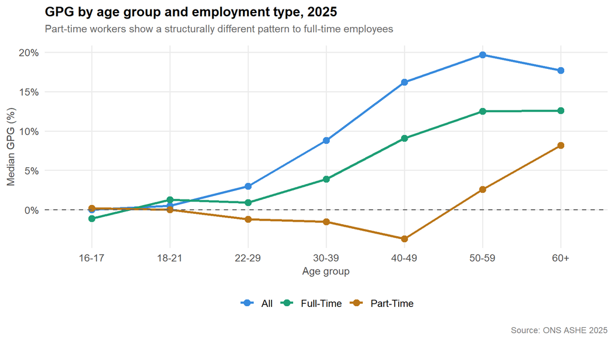

Figure 3: GPG by age group and employment type

```r
df_age_clean %>%
  filter(description != "All employees") %>%
  mutate(emp_type = factor(emp_type,
                           levels = c("All", "Full-Time", "Part-Time"))) %>%
  ggplot(aes(x = description, y = gpg_median,
             colour = emp_type, group = emp_type)) +
  geom_line(linewidth = 1.1) +
  geom_point(size = 3) +
  geom_hline(yintercept = 0, linetype = "dashed", colour = "grey40") +
  scale_colour_manual(values = c("All"       = COL_ALL,
                                 "Full-Time" = COL_FT,
                                 "Part-Time" = COL_PT)) +
  scale_y_continuous(labels = function(x) paste0(x, "%")) +
  labs(
    title    = "GPG by age group and employment type, 2025",
    subtitle = "Part-time workers show a structurally different pattern to full-time employees",
    x        = "Age group",
    y        = "Median GPG (%)",
    caption  = "Source: ONS ASHE 2025"
  ) +
  theme_gpg()
```

# 5. GPG by Industry

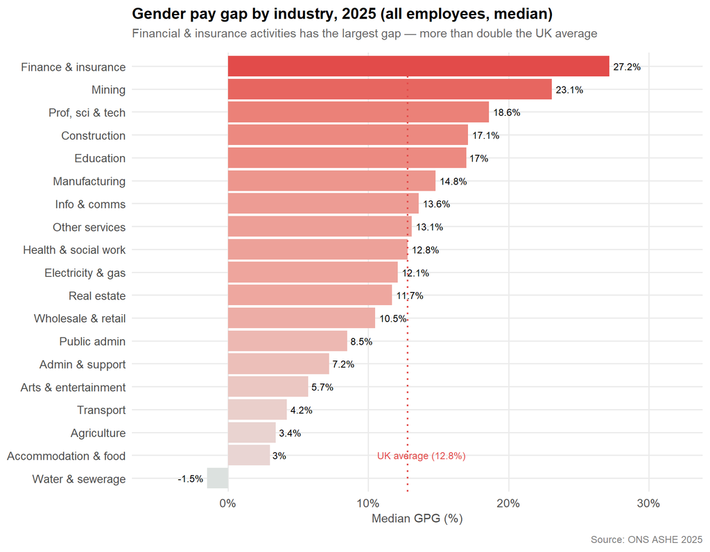

Figure 4: Median GPG by industry

```r
p4_data <- df_industry_clean %>%
  filter(emp_type == "All") %>%
  arrange(gpg_median) %>%
  mutate(short_label = factor(short_label, levels = short_label))

ggplot(p4_data, aes(x = short_label, y = gpg_median, fill = gpg_median)) +
  geom_col(show.legend = FALSE) +
  geom_hline(yintercept = 12.8, linetype = "dotted",
             colour = COL_POS, linewidth = 0.8) +
  annotate("text", x = 2, y = 13.8,
           label = "UK average (12.8%)",
           colour = COL_POS, size = 3.2) +
  geom_text(aes(label = paste0(round(gpg_median, 1), "%"),
                hjust = ifelse(gpg_median >= 0, -0.15, 1.15)),
            size = 3.2) +
  scale_fill_gradient2(low = COL_NEG, mid = "grey90",
                       high = COL_POS, midpoint = 0) +
  scale_y_continuous(labels = function(x) paste0(x, "%"),
                     limits = c(-5, 32)) +
  coord_flip() +
  labs(
    title    = "Gender pay gap by industry, 2025 (all employees, median)",
    subtitle = "Financial & insurance activities has the largest gap — more than double the UK average",
    x        = NULL,
    y        = "Median GPG (%)",
    caption  = "Source: ONS ASHE 2025"
  ) +
  theme_gpg()
```

```r
df_industry_clean %>%
  filter(emp_type == "All") %>%
  arrange(desc(gpg_median)) %>%
  select(Industry = short_label,
         `Median GPG (%)` = gpg_median,
         `Mean GPG (%)` = gpg_mean) %>%
  mutate(across(where(is.numeric), ~ round(., 1))) %>%
  knitr::kable(caption = "Table 2: GPG by industry, all employees (sorted by median GPG)")
```

Table 2: GPG by industry, all employees (sorted by median GPG)

| Industry | Median GPG (%) | Mean GPG (%) |
| --- | --- | --- |
| Finance & insurance | 27.2 | 27.9 |
| Mining | 23.1 | 13.9 |
| Prof, sci & tech | 18.6 | 16.5 |
| Construction | 17.1 | 11.5 |
| Education | 17.0 | 12.1 |
| Manufacturing | 14.8 | 8.1 |
| Info & comms | 13.6 | 10.6 |
| Other services | 13.1 | 11.1 |
| Health & social work | 12.8 | 19.3 |
| Electricity & gas | 12.1 | 11.5 |
| Real estate | 11.7 | 14.2 |
| Wholesale & retail | 10.5 | 12.0 |
| Public admin | 8.5 | 4.0 |
| Admin & support | 7.2 | 10.0 |
| Arts & entertainment | 5.7 | 26.5 |
| Transport | 4.2 | 6.7 |
| Agriculture | 3.4 | 2.8 |
| Accommodation & food | 3.0 | 4.8 |
| Water & sewerage | -1.5 | -7.5 |

> **Key finding:** Financial & insurance activities (27.2%) has a gap more than double the national average, likely driven by a highly male-dominated senior workforce. Water & sewerage (−1.5%) is the only sector where women out-earn men on the median.

# 6. GPG by Occupation

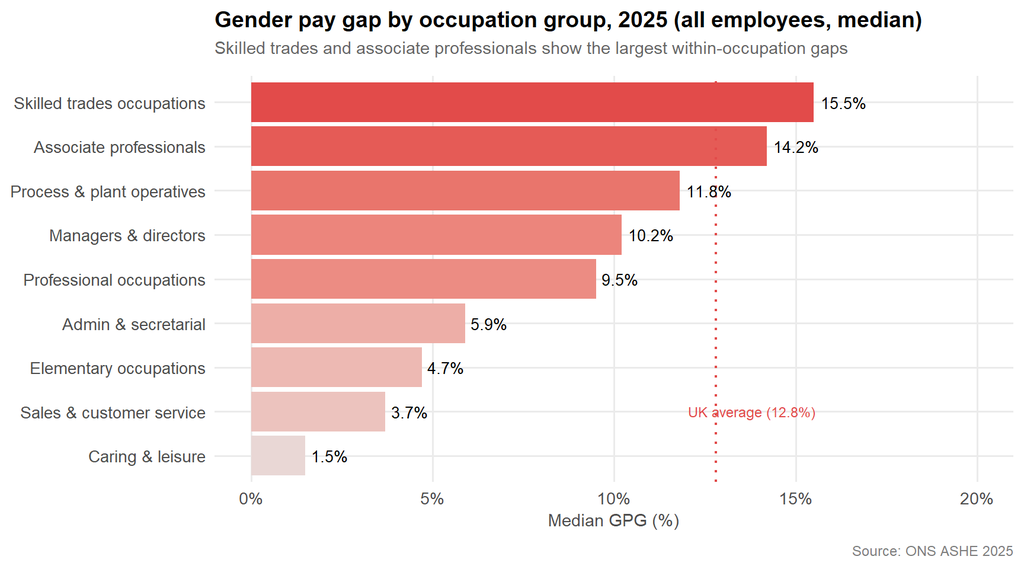

Figure 5: Median GPG by occupation group

```r
p5_data <- df_occupation_clean %>%
  filter(emp_type == "All") %>%
  arrange(gpg_median) %>%
  mutate(description = factor(description, levels = description))

ggplot(p5_data, aes(x = description, y = gpg_median, fill = gpg_median)) +
  geom_col(show.legend = FALSE) +
  geom_hline(yintercept = 12.8, linetype = "dotted",
             colour = COL_POS, linewidth = 0.8) +
  annotate("text", x = 2, y = 13.8,
           label = "UK average (12.8%)",
           colour = COL_POS, size = 3.2) +
  geom_text(aes(label = paste0(round(gpg_median, 1), "%"),
                hjust = ifelse(gpg_median >= 0, -0.15, 1.15)),
            size = 3.5) +
  scale_fill_gradient2(low = COL_NEG, mid = "grey90",
                       high = COL_POS, midpoint = 0) +
  scale_y_continuous(labels = function(x) paste0(x, "%"),
                     limits = c(0, 20)) +
  coord_flip() +
  labs(
    title    = "Gender pay gap by occupation group, 2025 (all employees, median)",
    subtitle = "Skilled trades and associate professionals show the largest within-occupation gaps",
    x        = NULL,
    y        = "Median GPG (%)",
    caption  = "Source: ONS ASHE 2025"
  ) +
  theme_gpg()
```